## Name: Sankalp Sandeep Indish

## Email: indishsankalp2004@gmail.com

# About Dataset

## Dataset Overview

This dataset contains sensor data collected from various machines, with the aim of predicting machine failures in advance. It includes a variety of sensor readings as well as the recorded machine failures.

## Columns Description

- footfall: The number of people or objects passing by the machine.
- temp Mode: The temperature mode or setting of the machine.
- AQ: Air quality index near the machine.
- USS: Ultrasonic sensor data, indicating proximity measurements.
- CS: Current sensor readings, indicating the electrical current usage of the machine.
- VOC: Volatile organic compounds level detected near the machine.
- RP: Rotational position or RPM (revolutions per minute) of the machine parts.
- IP: Input pressure to the machine.
- Temperature: The operating temperature of the machine.
- fail: Binary indicator of machine failure (1 for failure, 0 for no failure).

#### In summary, main task is to predict whether a machine will fail (fail column) using the sensor data as features.

## **Notes:** [Very important, please read]

### 1] I have used the following ways

- Logistic Regression
- Logistic Regression with Hyper-Parameter Tuning

### 2] Which parameter is more important? It's recall, here's why:-

- Recall focuses on the proportion of actual failures (positive cases) that model correctly identifies.
- In a machine failure prediction scenario, missing a failure (False Negative) could be costly or dangerous, as it might lead to an undetected machine failure
- **EG.** If a machine is predicted to pass (0) but actually fails (1), this is a False Negative, and such an error could lead to serious consequences.
- By optimizing for recall, we ensure that model catches as many failures as possible, even if that means sometimes predicting a failure when there isn’t one (False Positive).
- This could lead to more preventive maintenance, which might be preferable over the risk of missing a failure.

## 1] Importing the required Libraries

```python
import warnings
warnings.filterwarnings('ignore')

import pandas as pd
import seaborn as sns
import numpy as np
import matplotlib.pyplot as plt

from sklearn.model_selection import GridSearchCV, train_test_split
from sklearn.linear_model import LogisticRegression
from sklearn.metrics import accuracy_score, precision_score, recall_score, f1_score, roc_auc_score, classification_report, roc_curve, auc
from sklearn.preprocessing import StandardScaler
from sklearn.ensemble import RandomForestClassifier
```

## 2] Importing the required dataset

```python
machine_data = pd.read_csv('/content/data.csv')
```

## 3] Understanding few insights

```python
machine_data.head(3)
```

|  | footfall | tempMode | AQ | USS | CS | VOC | RP | IP | Temperature | fail |
| --- | --- | --- | --- | --- | --- | --- | --- | --- | --- | --- |
| 0 | 0 | 7 | 7 | 1 | 6 | 6 | 36 | 3 | 1 | 1 |
| 1 | 190 | 1 | 3 | 3 | 5 | 1 | 20 | 4 | 1 | 0 |
| 2 | 31 | 7 | 2 | 2 | 6 | 1 | 24 | 6 | 1 | 0 |

```python
machine_data.info()
```

```
<class 'pandas.core.frame.DataFrame'>
RangeIndex: 944 entries, 0 to 943
Data columns (total 10 columns):
 #   Column       Non-Null Count  Dtype
---  ------       --------------  -----
 0   footfall     944 non-null    int64
 1   tempMode     944 non-null    int64
 2   AQ           944 non-null    int64
 3   USS          944 non-null    int64
 4   CS           944 non-null    int64
 5   VOC          944 non-null    int64
 6   RP           944 non-null    int64
 7   IP           944 non-null    int64
 8   Temperature  944 non-null    int64
 9   fail         944 non-null    int64
dtypes: int64(10)
memory usage: 73.9 KB
```

```python
# Thus we have 10 columns and 944 rows
```

## 4] Check for Null Values

```python
machine_data.isnull().sum()
```

|  | 0 |
| --- | --- |
| footfall | 0 |
| tempMode | 0 |
| AQ | 0 |
| USS | 0 |
| CS | 0 |
| VOC | 0 |
| RP | 0 |
| IP | 0 |
| Temperature | 0 |
| fail | 0 |

**dtype:** int64

```python
# There is no null value present.
```

```python
# Our Dependent Variable [output] [y]: fail
# Our Independent Variables [input] [x]: Remaining Cols
```

## 5] Understanding which features correlate the best

```python
machine_data.describe()
```

|  | footfall | tempMode | AQ | USS | CS | VOC | RP | IP | Temperature | fail |
| --- | --- | --- | --- | --- | --- | --- | --- | --- | --- | --- |
| count | 944.000000 | 944.000000 | 944.000000 | 944.000000 | 944.000000 | 944.000000 | 944.000000 | 944.000000 | 944.000000 | 944.000000 |
| mean | 306.381356 | 3.727754 | 4.325212 | 2.939619 | 5.394068 | 2.842161 | 47.043432 | 4.565678 | 16.331568 | 0.416314 |
| std | 1082.606745 | 2.677235 | 1.438436 | 1.383725 | 1.269349 | 2.273337 | 16.423130 | 1.599287 | 5.974781 | 0.493208 |
| min | 0.000000 | 0.000000 | 1.000000 | 1.000000 | 1.000000 | 0.000000 | 19.000000 | 1.000000 | 1.000000 | 0.000000 |
| 25% | 1.000000 | 1.000000 | 3.000000 | 2.000000 | 5.000000 | 1.000000 | 34.000000 | 3.000000 | 14.000000 | 0.000000 |
| 50% | 22.000000 | 3.000000 | 4.000000 | 3.000000 | 6.000000 | 2.000000 | 44.000000 | 4.000000 | 17.000000 | 0.000000 |
| 75% | 110.000000 | 7.000000 | 6.000000 | 4.000000 | 6.000000 | 5.000000 | 58.000000 | 6.000000 | 21.000000 | 1.000000 |
| max | 7300.000000 | 7.000000 | 7.000000 | 7.000000 | 7.000000 | 6.000000 | 91.000000 | 7.000000 | 24.000000 | 1.000000 |

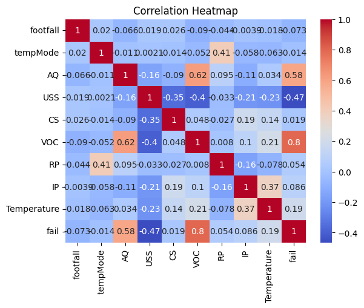

```python
# Filter out only numeric columns (int and float)
# This is because string and float cannot be correlated
numeric_machine_data = machine_data.select_dtypes(include=['int64', 'float64'])

correlation_matrix = numeric_machine_data.corr()

sns.heatmap(correlation_matrix, annot=True, cmap='coolwarm')
plt.title('Correlation Heatmap')
plt.show()
```

#### For best results, we will consider:-

- The correlation is 0.30 and above are best correlated
- 1] fail and AQ -> +0.58
- 2] fail and USS -> -0.47
- 3] fail and VOC -> +0.8
- As AQ, VOC, and USS are the strongest features of output "fail"

### Understand if any outliers are present

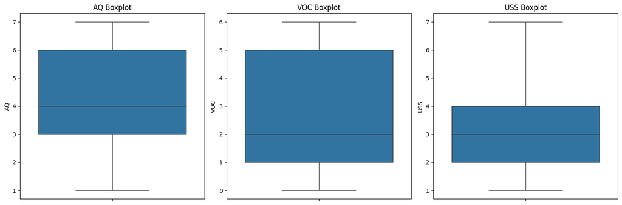

```python
# Create a figure with multiple subplots
fig, axes = plt.subplots(1, 3, figsize=(15, 5))

# Boxplot for AQ
sns.boxplot(ax=axes[0], data=numeric_machine_data, y='AQ')
axes[0].set_title('AQ Boxplot')

# Boxplot for VOC
sns.boxplot(ax=axes[1], data=numeric_machine_data, y='VOC')
axes[1].set_title('VOC Boxplot')

# Boxplot for USS
sns.boxplot(ax=axes[2], data=numeric_machine_data, y='USS')
axes[2].set_title('USS Boxplot')

# Display the plots
plt.tight_layout()
plt.show()
```

```python
# Thus we can see that there are no outliers present
```

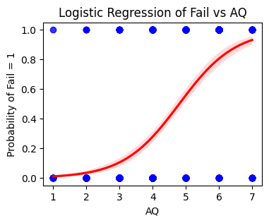

```
Correlation Percentage:  58.32376531019058
```

```python
# Correlation between fail and AQ
x = numeric_machine_data['AQ']
y = numeric_machine_data['fail']

# Logistic Regression plot for AQ
plt.figure(figsize=(4, 3))
sns.regplot(x='AQ', y='fail', data=numeric_machine_data, logistic=True, scatter_kws={"color": "blue"}, line_kws={"color": "red"})

# Adding titles and labels
plt.title('Logistic Regression of Fail vs AQ')
plt.xlabel('AQ')
plt.ylabel('Probability of Fail = 1')
plt.show()

# Correlation percentage
corr_percent = (x.corr(y) * 100)
print("Correlation Percentage: ", corr_percent)
```

- The curve starts low (near 0), representing a low probability of failure for low AQ values.
- As AQ increases, the probability of failure increases gradually and approaches 1 (indicating a higher likelihood of failure as AQ rises).

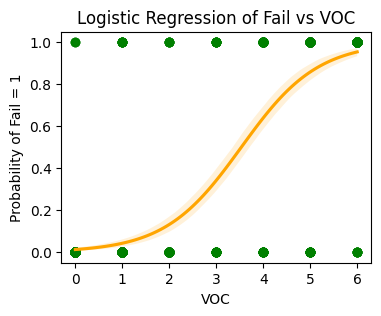

```
Correlation Percentage:  79.73291472397247
```

```python
# Correlation between fail and AQ
x = numeric_machine_data['VOC']
y = numeric_machine_data['fail']

# Logistic regression plot for VOC
plt.figure(figsize=(4, 3))
sns.regplot(x='VOC', y='fail', data=numeric_machine_data, logistic=True, scatter_kws={"color": "green"}, line_kws={"color": "orange"})

# Adding titles and labels
plt.title('Logistic Regression of Fail vs VOC')
plt.xlabel('VOC')
plt.ylabel('Probability of Fail = 1')
plt.show()

# Correlation percentage
corr_percent = (x.corr(y) * 100)
print("Correlation Percentage: ", corr_percent)
```

- The curve starts low (near 0), representing a very low probability of failure when VOC is low (at VOC = 0).
- As VOC increases, the probability of failure rises sharply.
- By the time VOC reaches 6, the probability of failure is near 1, meaning machines with higher VOC values are very likely to fail.
- Overall, there is a positive relationship between VOC and the likelihood of failure: as VOC increases, the chance of failure increases significantly.

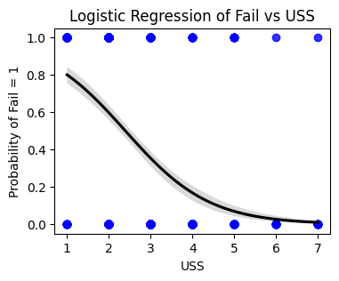

```
Correlation Percentage:  -46.657374530547266
```

```python
# Correlation between fail and USS
x = numeric_machine_data['USS']
y = numeric_machine_data['fail']

# Logistic regression plot for USS
plt.figure(figsize=(4, 3))
sns.regplot(x='USS', y='fail', data=numeric_machine_data, logistic=True, scatter_kws={"color": "blue"}, line_kws={"color": "black"})

# Adding titles and labels
plt.title('Logistic Regression of Fail vs USS')
plt.xlabel('USS')
plt.ylabel('Probability of Fail = 1')
plt.show()

# Correlation percentage
corr_percent = (x.corr(y) * 100)
print("Correlation Percentage: ", corr_percent)
```

- The curve starts high (near 0.8), indicating a high probability of failure when USS is low (at USS = 1).
- As USS increases, the probability of failure decreases gradually.
- By the time USS reaches 7, the probability of failure is near 0, meaning machines with higher USS values are much less likely to fail.
- Overall, there is an inverse relationship between USS and the likelihood of failure: as USS increases, the chance of failure decreases.

## 6.1] Describing correlation variables

```python
feature_col = ['AQ', 'VOC', 'USS']
x = numeric_machine_data[feature_col]
y = numeric_machine_data.fail
```

## 6.2] Scaling the data

```python
scaler = StandardScaler()
x_scaled = scaler.fit_transform(x)
```

## 7] Splitting data into test and training data

```python
x_train, x_test, y_train, y_test = train_test_split(x_scaled, y, test_size=0.2, random_state=42)
```

```python
display(x_train.shape)
display(y_train.shape)
print()
display(x_test.shape)
display(y_test.shape)
```

```
(755, 3)
```

```
(755,)
```

```
(189, 3)
```

```
(189,)
```

## 8] Logistic Regression

```python
# Fitting the model
model = LogisticRegression(solver='lbfgs', max_iter=1000)
model.fit(x_train, y_train)
y_pred = model.predict(x_test)
```

```python
# feature_col = ['AQ', 'VOC', 'USS']
features = np.array([[3, 12, 1]])
print("The pass/fail result is:", model.predict(features))
y_pred = model.predict(x_test)
y_prob = model.predict_proba(x_test)[:, 1]
```

```
The pass/fail result is: [1]
```

```python
# Accuracy: Indicates that the model correctly predicted the outcome approximately how much times
accuracy = accuracy_score(y_test, y_pred)
print(f"Accuracy: {accuracy:.2f}")
```

```
Accuracy: 0.88
```

```python
# Precision: Precision measures the proportion of true positive predictions among all positive prediction
precision = precision_score(y_test, y_pred)
print(f'Precision: {precision:.2f}')
```

```
Precision: 0.86
```

```python
# Recall: Recall (or Sensitivity) measures the proportion of true positive predictions among all actual positives.
recall = recall_score(y_test, y_pred)
print(f'Recall: {recall:.2f}')
```

```
Recall: 0.90
```

```python
# F1 Score: F1-Score is the harmonic mean of precision and recall.
# It’s a balanced measure that considers both false positives and false negatives.
f1 = f1_score(y_test, y_pred)
print(f'F1-Score: {f1:.2f}')
```

```
F1-Score: 0.88
```

```python
# ROC-AUC: ROC-AUC measures the area under the receiver operating characteristic (ROC) curve.
# It represents the model's ability to distinguish between positive and negative classes.
roc_auc = roc_auc_score(y_test, y_prob)
print(f'ROC-AUC: {roc_auc:.6f}')
```

```
ROC-AUC: 0.950079
```

## 9] Hyper-parameter tuning

```python
grid_feature_col = ['AQ', 'VOC', 'USS']

grid_x = numeric_machine_data[grid_feature_col]
grid_y = numeric_machine_data['fail']

# Splitting the data into training and testing sets
grid_x_train, grid_x_test, grid_y_train, grid_y_test = train_test_split(grid_x, grid_y, test_size=0.2, random_state=42)
```

```python
# Logistic Regression model for tuning
tuned_model = LogisticRegression()
```

```python
# Setting up the hyperparameter grid for tuning
param_grid = [
    {'penalty':['l1','l2','elasticnet','none'],
    'C' : np.logspace(-4,4,20),
    'solver': ['lbfgs','newton-cg','liblinear','sag','saga'],
    'max_iter'  : [100,1000,2500,5000]
}
]
```

```python
# GridSearchCV to tune hyperparameters
grid_search = GridSearchCV(tuned_model, param_grid, cv=5, verbose=1, n_jobs=-1)
```

```python
# Fitting the model to the training data
grid_search.fit(grid_x_train, grid_y_train)
```

```
Fitting 5 folds for each of 1600 candidates, totalling 8000 fits
```

```
GridSearchCV(cv=5, estimator=LogisticRegression(), n_jobs=-1,
             param_grid=[{'C': array([1.00000000e-04, 2.63665090e-04, 6.95192796e-04, 1.83298071e-03,
       4.83293024e-03, 1.27427499e-02, 3.35981829e-02, 8.85866790e-02,
       2.33572147e-01, 6.15848211e-01, 1.62377674e+00, 4.28133240e+00,
       1.12883789e+01, 2.97635144e+01, 7.84759970e+01, 2.06913808e+02,
       5.45559478e+02, 1.43844989e+03, 3.79269019e+03, 1.00000000e+04]),
                          'max_iter': [100, 1000, 2500, 5000],
                          'penalty': ['l1', 'l2', 'elasticnet', 'none'],
                          'solver': ['lbfgs', 'newton-cg', 'liblinear', 'sag',
                                     'saga']}],
             verbose=1)
```

```python
# Best parameters from GridSearch
grid_best_params = grid_search.best_params_
```

```python
# Predicting on the test set
grid_y_pred = grid_search.predict(grid_x_test)
grid_y_prob = grid_search.predict_proba(grid_x_test)[:, 1]
```

```python
# Display best parameters
print(f"Best Parameters: {grid_best_params}")
```

```
Best Parameters: {'C': 0.08858667904100823, 'max_iter': 100, 'penalty': 'l2', 'solver': 'saga'}
```

```python
# Display accuracy
grid_accuracy = accuracy_score(grid_y_test, grid_y_pred)
print(f"Accuracy: {grid_accuracy:.2f}")
```

```
Accuracy: 0.88
```

```python
# Display precision
grid_precision = precision_score(grid_y_test, grid_y_pred)
print(f'Precision: {grid_precision:.2f}')
```

```
Precision: 0.86
```

```python
# Display recall
grid_recall = recall_score(grid_y_test, grid_y_pred)
print(f'Recall: {grid_recall:.2f}')
```

```
Recall: 0.90
```

```python
# Display f1-score
grid_f1 = f1_score(grid_y_test, grid_y_pred)
print(f'F1-Score: {grid_f1:.2f}')
```

```
F1-Score: 0.88
```

```python
# Display roc-auc
grid_roc_auc = roc_auc_score(grid_y_test, grid_y_prob)
print(f'ROC-AUC: {grid_roc_auc:.2f}')
```

```
ROC-AUC: 0.95
```

## 13] User-Defined Model Testing

#### Below we cross tally the result with user-defined input

```python
# The ready model testing:-
# feature_col = ['AQ', 'VOC', 'USS']
AQ = int(input("Enter AQ: "))
VOC = int(input("Enter VOC: "))
USS = int(input("Enter USS: "))

features = np.array([[AQ, VOC, USS]])

print("The pass/fail result is:", grid_search.predict(features))

# Printing the understanding
if(grid_search.predict(features) == 1):
  print("The machine will fail")
else:
  print("The machine will not fail")
```

```
Enter AQ: 7
Enter VOC: 6
Enter USS: 1
The pass/fail result is: [1]
The machine will fail
```

```python
# Fetching record to see, what is the output for user defined input
first_record_df = numeric_machine_data.head(1)
print(first_record_df)
```

```
   footfall  tempMode  AQ  USS  CS  VOC  RP  IP  Temperature  fail
0         0         7   7    1   6    6  36   3            1     1
```

# Thanks for analyzing so far, drop your suggestions to: indishsankalp2004@gmail.com